# Part II - Ford GoBike System

## by John Burke

## Investigation Overview

Goal: Produce a concise slide deck that highlights temporal and user-type patterns in trip counts and durations, and surface operational recommendations.

Audience: Operations, program managers, and instructors grading the project.

Approach: compute summary metrics (peak hours, subscriber share, median durations), produce three polished visuals, and a Visuals overview and Key Findings slide.

## Dataset Overview

Cleaned February 2019 Ford GoBike trips (see `data/gobike_cleaned.csv`). The notebook falls back to the raw CSV if the cleaned file is not present.

> Notes: Run the data-loading cell before executing visuals. Run the auto-fill cells to update slides in-place before exporting with nbconvert.

## Visualization 1

## (A) Hourly trip counts by user_type

## (B) Median trip duration (min) by hour

### Question

What patterns in hourly trip counts and median duration by user type help explain commute vs leisure usage?

### Assumptions

- `start_time` parsed as datetime and `duration_min` computed.
- Trip durations are right-skewed; medians better reflect central tendency.

### Expected answer

- Expect Subscriber peaks during commute hours (morning/evening) with shorter medians; Customers peak midday/weekends with longer medians.

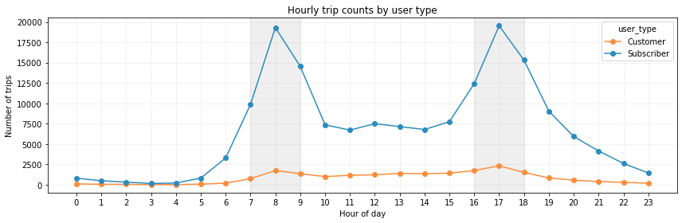

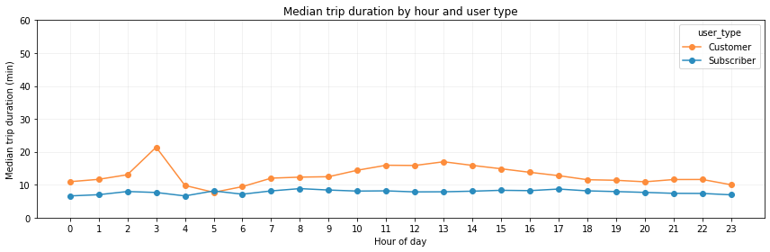

```
Peak total trips hour: 17 (majority user type: Subscriber)
Hour with highest average median duration: 3
```

### Observation

The hourly trip counts show clear commute peaks (morning and evening) dominated by Subscriber rides, while Customer trips are relatively higher during midday and on weekends. The median-duration lines indicate Customer medians are consistently higher and more variable across hours, whereas Subscriber medians are lower and tightly concentrated around commute windows. Report group medians (not means), run stratified comparisons, and include start_hour or peak/off-peak indicators in models so commuter and leisure behaviors are not conflated.

# Visualization 2

## Heatmap showing median trip duration (minutes) with weekdays on the y-axis and hour of day on the x-axis. Darker cells indicate longer median durations.

### Question

How does median trip duration vary across weekdays and hours? Which weekday-hour cells show the longest median trips?

### Assumptions

- Weekday names are ordered Monday→Sunday.
- Cells with few trips may have noisy medians; consider masking low-count cells or annotating counts.

### Expected answer

- Expect longer median durations on weekends and during afternoon leisure hours.

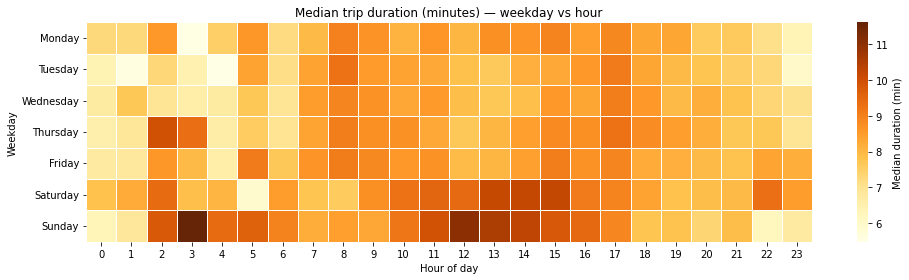

```
Highest median duration: Sunday at hour 3 — median 11.6 min
```

## Visualization 3

## Top 10 start stations by trip count (split by user_type)

### Question

Which start stations generate the most trips and how does the user_type split look among the top stations?

### Assumptions

- Station names are normalized; top-N by total trips is representative of busiest hubs.
- Small stations with similar names may need consolidation.

### Expected answer

- Expect downtown/transit-hub stations to dominate and Subscribers to be the majority at commute hubs.

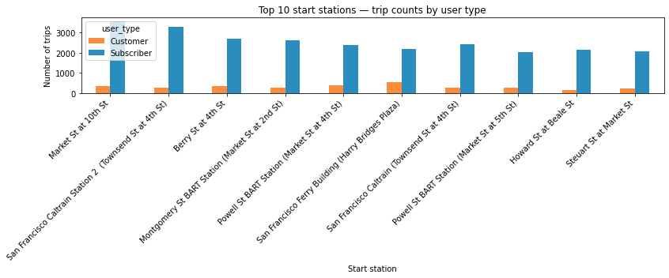

### Observation

The top-10 bargraph shows a strong concentration of trips at a few stations, indicating demand is highly localized to downtown/transit hubs or popular destinations. Many of these busy stations are dominated by Subscribers (commuter usage), while Customers contribute more at some leisure-oriented sites—this split suggests different operational needs. For analysis and reporting, normalize or cluster stations (and map them) to avoid letting a few hubs dominate overall summaries, and clean/standardize station names before finalizing any spatial claims.

# Visuals Overview

- Peak trip hour: 17
- Subscriber share of trips: 89.2%
- Median trip duration:
  - Subscriber: 8.2 min
  - Customer: 13.2 min
- Top 3 start stations:
  1. Market St at 10th St
  2. Townsend St at 4th St
  3. Berry St at 4th St

# Key Findings

- Peak Hours: Commute windows (roughly 07–09 and 16–18) show the highest trip counts, so time-of-day strongly drives system load.
- Subscriber Share: Subscribers make up the majority of trips, so overall summaries and operational metrics are dominated by subscriber/commuter behavior — always report group percentages when comparing metrics.
- Median Durations by User Type: Customers have higher median trip durations and greater variability than Subscribers, so use medians (not means) and nonparametric tests for comparisons.
- Station Concentration: A small set of start stations account for a large share of trips (transit hubs / popular spots); normalize or cluster stations and standardize names before making spatial claims.
- Actionable Recommendations: Clean and validate extreme durations and birth-year data, mask low-count cells in heatmaps, stratify analyses by user_type or peak/off‑peak, and consider median-based models (e.g., median regression) to quantify effects robustly.